# Cascaded integrator–comb (CIC) filters

```python
from math import log
import numpy as np
import matplotlib.pyplot as plt
np.seterr(divide='ignore', invalid='ignore');
fftResolution = 1024
```

## Introduction

CIC filters are computationally efficient implementations of narrowband lowpass filters. They are particularly suited for use as an anti-aliasing filter when decimating or an anti-image filter when interpolating. CIC filters are well suited for implementation in FPGAs and ASICs as they only require addition and subtraction operations and not multiplication [1].

CIC filters have a non-flat passband and as such are typically used in combination with a FIR filter which compensates for the passband droop [2]. In both interpolation and decimation, the FIR filter operates at the lower sample rate allowing for efficient FIR implementations that can take advantage of time-sharing.

- [1] Lyons, R. *Understanting Digital Signal Processing. Third Edition*, pp. 550-565
- [2] Altera Corporation, *Understanding CIC Compensation Filters. Application Note 455*

## How do CIC filters work?

The best way to understand how a CIC filter works is to start with a simple moving average filter and gradually work towards the efficient implementation of a CIC filter. Additionally, while CIC filters are almost always used as part of a resampling operation it is best to initially analyse them purely as a single rate filter.

### Moving average filter

A D point moving average filter sums the current sample with the previous D-1 samples and multiplies the result by 1/D.

[figure not shown]

The magnitude of the frequency response of a moving average filter is given by: $$\left | H(\omega ) \right | = \frac{1}{D}\left | \frac{\sin \left ( \frac{\omega D}{2} \right )}{\sin \left ( \frac{\omega }{2} \right )} \right |$$

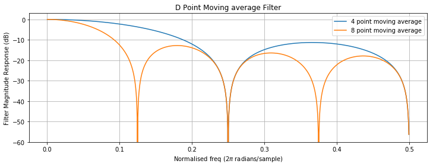

```python
plt.figure(figsize=(12,4))
def movingAverageFreqResponse(D):
    Hfunc = lambda w : np.abs( (np.sin((w*D)/2.0)) / (np.sin((w)/2.0)) ) * (1.0/D)
    w = np.arange(fftResolution) * np.pi/fftResolution
    H = np.array(list(map(Hfunc, w)))
    plt.plot(w/(2*np.pi),(20*np.log10((H))), label="{} point moving average".format(D))

movingAverageFreqResponse(4)
movingAverageFreqResponse(8)
axes = plt.gca()
axes.set_ylim([-60,3])
plt.grid()
plt.legend()
plt.title('D Point Moving average Filter')
plt.xlabel('Normalised freq (2$\pi$ radians/sample)')
plt.ylabel('Filter Magnitude Response (dB)')
plt.show()
```

It can be seen that a moving average filter is a lowpass filter with a sinc like frequency response. The location of the first null is set by the number of points the moving average is calculated over. For a 4-point moving average filter there is a null at fs/4 and 2*fs/4 where fs is the sample rate. In general, there will be nulls at intervals of fs/D.

### Running sum filter

It can be seen that removing the multiplication by 1/D will cause there to be a gain of D, but otherwise the frequency response is unchanged. A moving average filter without the multiplication by 1/D is known as a running sum filter.

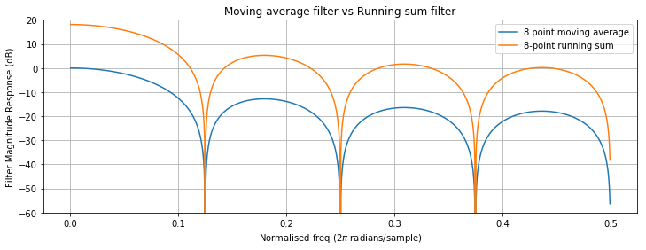

```python
plt.figure(figsize=(12,4))
def runningSumFreqResponse(D):
    Hfunc = lambda w : np.abs( (np.sin((w*D)/2.0)) / (np.sin((w)/2.0)) )
    w = np.arange(fftResolution) * np.pi/fftResolution
    H = np.array(list(map(Hfunc, w)))
    plt.plot(w/(2*np.pi),(20*np.log10((H))), label="{}-point running sum".format(D))

movingAverageFreqResponse(8)
runningSumFreqResponse(8)
axes = plt.gca()
axes.set_ylim([-60,20])
plt.grid()
plt.legend()
plt.title('Moving average filter vs Running sum filter')
plt.xlabel('Normalised freq (2$\pi$ radians/sample)')
plt.ylabel('Filter Magnitude Response (dB)')
plt.show()
```

Both the moving average filter and the running sum filter require D-1 summations to compute each output sample. A recursive running sum filter performs the same operation but only needs to compute one addition and one subtraction per output sample.

[figure not shown]

It is relatively intuitive that this produces the same response as the regular running sum filter. The integrator at the output sums every sample that enters it, however left part of the filter (the comb) ensures that for every sample that is added to the integrator, D inputs later it will be subtracted from integrator. The integrator can be thought of as keeping track of the sum of what would have been inside the running sum window.

The filter is stable providing the additions and subtractions are performed exactly. It is for this reason that a recursive running sum filter, and as we will see later a CIC filter, will only work with fixed point maths; the errors introduced by floating point calculations would eventually accumulate in the integrator.

### CIC filter

As it turns out a recursive running sum filter is actually CIC filter of order 1.

[figure not shown]

#### Comb then integrator or integrator then comb?

Both the integrator and comb are linear time-invariant operations. This means we can swap the integrator and comb sections without changing the output. It is worth pointing out that with the integrator first the output of the integrator could be massive, but providing the system is implemented using 2-complement maths, and the bit widths are sufficient to hold the final output sample the integrator will simply wrap round without causing any issues. The bit widths required to implement a CIC filter will be covered later.

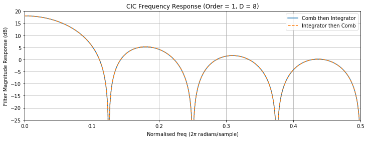

```python
# NB The comb and integrator are implemented for clarity and not efficiency!
def comb(inData, D):
    outData = []
    delay = [0] * D
    for sample in inData:
        outData.append(sample - delay[-1])
        delay = [sample] + delay
        delay.pop()
    return outData

def integrator(inData):
    delay = 0
    outData = []
    for sample in inData:
        y = delay + sample
        outData.append(y)
        delay = y
    return outData

impulse = [1]+[0]*(fftResolution)
impulseResponse = integrator(comb(impulse, 8)) # Apply the comb with delay 8, then the integrator.
impulseResponse2 = comb(integrator(impulse),8) # Apply the integrator, then the comb with delay 8.
# Plot result
# Only plot the positive frequencies (-ive freqs are just an image of +ive)
xaxis = np.arange(fftResolution/2) * 0.5/(fftResolution/2)
plt.figure(figsize=(12,4))
plt.plot(xaxis,(20*np.log10(np.abs(np.fft.fft(impulseResponse))))[0:int(fftResolution/2)], label="Comb then Integrator")
plt.plot(xaxis,(20*np.log10(np.abs(np.fft.fft(impulseResponse2))))[0:int(fftResolution/2)],'--', label="Integrator then Comb")
axes = plt.gca()
axes.set_xlim([0,0.5])
axes.set_ylim([-25,20])
plt.grid()
plt.legend()
plt.title('CIC Frequency Response (Order = 1, D = 8)')
plt.xlabel('Normalised freq (2$\pi$ radians/sample)')
plt.ylabel('Filter Magnitude Response (dB)')
plt.show()
```

For optimisation reasons, which we will soon cover, when used for decimation the integration operation is performed first, followed by the comb. For interpolation the opposite is true with the comb operation coming first, followed by the integration.

[figure not shown]

#### Setting the delay (D) value

Typically if we wish to interpolate or decimate by a factor of R then D is set to an integer multiple of R, normally 1 or 2. By making sure that D is an integer multiple of R some optimisations can be made in the implementation of the CIC filter. Typically it is noted as D = M*R where M is called the differential delay.

In the graph below the filter response of a CIC filter is shown for when M is 1 and 2.

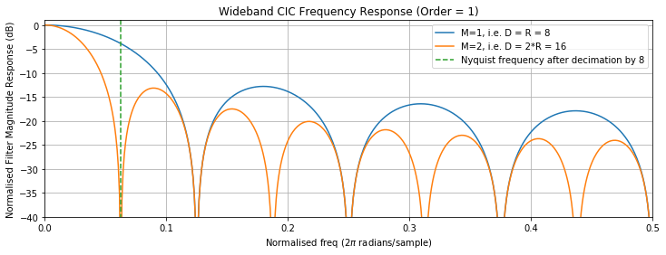

```python
plt.figure(figsize=(12,4))
impulse = [1]+[0]*(fftResolution)
impulseResponse3 = np.array(comb(integrator(impulse), 8))/8 # Divided by 8 to normalise gain
impulseResponse4 = np.array(comb(integrator(impulse),16))/16 # Divided by 16 to normalise gain
# Plot result
xaxis = np.arange(fftResolution/2) * 0.5/(fftResolution/2)
plt.plot(xaxis,(20*np.log10(np.abs(np.fft.fft(impulseResponse3))))[0:int(fftResolution/2)], label="M=1, i.e. D = R = 8")
plt.plot(xaxis,(20*np.log10(np.abs(np.fft.fft(impulseResponse4))))[0:int(fftResolution/2)], label="M=2, i.e. D = 2*R = 16")
plt.plot([0.0625,0.0625],[-45,1], '--', label="Nyquist frequency after decimation by 8")
axes = plt.gca()
axes.set_xlim([0,0.5])
axes.set_ylim([-40,1])
plt.grid()
plt.legend()
plt.title('Wideband CIC Frequency Response (Order = 1)')
plt.xlabel('Normalised freq (2$\pi$ radians/sample)')
plt.ylabel('Normalised Filter Magnitude Response (dB)')
plt.show()
```

The vertical dotted line in the above graph shows the Nyquist frequency after a decimation by a factor of 8. After decimation everything to the right of the line will be aliased into the passband of the filter. The aliases will be attenuated according to the frequency response shown in the graph. If this filter was used for interpolation then everything to the left of the green line would appear imaged throughout the new bandwidth. The images would be attenuated according to the frequency response shown in the graph.

#### Increasing CIC Attenuation

It is often important to achieve as much attenuation as possible. The frequency response of an order-1 CIC filter would not be sufficient in many applications. The attenuation can be increased by increasing the CIC order.

With a CIC filter the order is increased by simply cascading additional integrator and comb sections. The number of integrators and combs must be equal. An order-1 CIC has one integrator and one comb, an order-2 has two integrators and two combs, etc.

[figure not shown]

The magnitude of the CIC filter frequency response of order N is given by: $$\left | H(\omega ) \right | = \left | \frac{\sin \left ( \frac{\omega M}{2} \right )}{\sin \left ( \frac{\omega }{2R} \right )} \right |^{N}$$

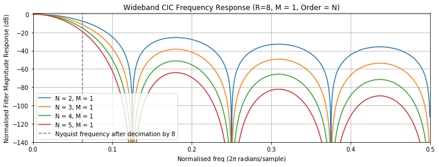

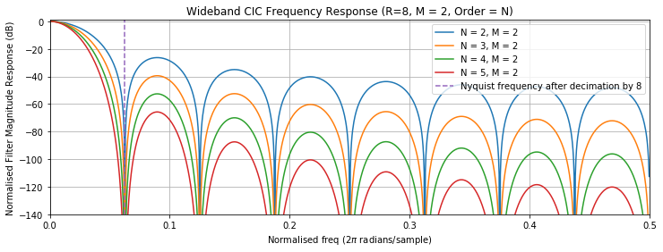

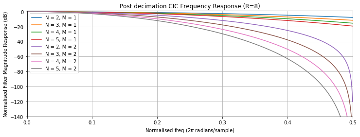

```python
plt.figure(figsize=(12,4))
def plotCICResponse(R,M,N, widebandResponse=1):

    Hfunc = lambda w : np.abs( (np.sin((w*M)/2.)) / (np.sin(w/(2.*R))) )**N

    if widebandResponse:
        # 0 to R*pi
        w = np.arange(fftResolution) * np.pi/fftResolution * R
    else:
        # 0 to pi
        w = np.arange(fftResolution) * np.pi/fftResolution

    gain = (M*R)**N
    xAxis = np.arange(fftResolution) / (fftResolution * 2)
    magResponse = np.array(list(map(Hfunc, w)))
    plt.plot(xAxis, 20.0*np.log10(magResponse/gain), label="N = {}, M = {}".format(N,M))

def plotConfig(title):
    axes = plt.gca(); axes.set_xlim([0,0.5]); axes.set_ylim([-140,1])
    plt.grid(); plt.legend()
    plt.title(title)
    plt.xlabel('Normalised freq (2$\pi$ radians/sample)')
    plt.ylabel('Normalised Filter Magnitude Response (dB)')
    plt.show()

# Plot 1
plt.figure(figsize=(12,4))
plotCICResponse(R=8,M=1,N=2)
plotCICResponse(R=8,M=1,N=3)
plotCICResponse(R=8,M=1,N=4)
plotCICResponse(R=8,M=1,N=5)
plt.plot([0.0625,0.0625],[-140,1], '--', label="Nyquist frequency after decimation by 8")
plotConfig("Wideband CIC Frequency Response (R=8, M = 1, Order = N)")
# Plot 2
plt.figure(figsize=(12,4))
plotCICResponse(R=8,M=2,N=2)
plotCICResponse(R=8,M=2,N=3)
plotCICResponse(R=8,M=2,N=4)
plotCICResponse(R=8,M=2,N=5)
plt.plot([0.0625,0.0625],[-140,1], '--', label="Nyquist frequency after decimation by 8")
axes = plt.gca(); axes.set_xlim([0,0.5]); axes.set_ylim([-140,1])
plotConfig("Wideband CIC Frequency Response (R=8, M = 2, Order = N)")
# Plot 3
plt.figure(figsize=(12,4))
plotCICResponse(R=8,M=1,N=2, widebandResponse=0)
plotCICResponse(R=8,M=1,N=3, widebandResponse=0)
plotCICResponse(R=8,M=1,N=4, widebandResponse=0)
plotCICResponse(R=8,M=1,N=5, widebandResponse=0)
plotCICResponse(R=8,M=2,N=2, widebandResponse=0)
plotCICResponse(R=8,M=2,N=3, widebandResponse=0)
plotCICResponse(R=8,M=2,N=4, widebandResponse=0)
plotCICResponse(R=8,M=2,N=5, widebandResponse=0)
plotConfig("Post decimation CIC Frequency Response (R=8)")
```

## Gain of a CIC

CIC filters have an inherent gain as a result of summing the D delayed samples. It is common to cancel out the gain after the CIC filter by multiplying by $\frac{1}{gain}$. Additionally, it is often possible to design the filter such that the gain is a power of two and can be cancelled using a binary right shift operation.

*NB. This gain has been cancelled out in most of the plots above in order to make the plots easier to compare.*

### Decimator

For a decimator the gain is given by:

$Gain = D^{N} = \left ( RM \right )^{N}$ where R = decimation factor, M = Differential delay, and N = CIC order

When implementing a CIC decimator the register size must be set according to the formula below or overflows errors will occur.

$registerWidth = inputDataWidth + \left \lceil N\log_{2}\left ( RM \right ) \right \rceil$

i.e. for a 16bit input word decimated by 8 with a CIC of order 3 and a differential delay of 1 the size of the registers used to store the integrator and comb data must be at least $16 + \left \lceil 3\log_{2}\left ( 8*1 \right ) \right \rceil = 25 bits$

### Interpolator

When interpolating, as a result of the zero padding, there is a gain of $\frac{1}{R}$ in addition to the gain of the CIC. As a result the gain of a CIC interpolator is given by:

$Gain = \frac{\left ( RM \right )^{N} }{R}$ where R = interpolation factor, M = Differential delay, and N = CIC order

When implementing a CIC interpolator the register size must be set according to the formula below or overflows errors will occur.

$registerWidth = inputDataWidth + \left \lceil \frac{N\log_{2}\left ( RM \right )}{\log_{2}\left (R\right)} \right \rceil$

## Implementing the CIC

Until now we have kept the resampler separate from the CIC filter in order to make analysis easier. The key advantage of CICs are their computational efficiency when resampling. In order to achieve this computational efficiency, it is possible to slide the resampler through the comb section of the CIC.

In the case of the decimator the down-sampler is moved back through the comb. A comb with a delay of D followed by a rate-R down-sampler will produce exactly the same results as a rate-R down-sampler followed by a comb with a delay of D/R. Since we set D to always be an integer multiple (M) of R, the delay can be set to: $\frac{D}{R} = \frac{RM}{R} = M$.

In the case of the interpolator the up-sampler is moved forwards through the comb. An rate-R up-sampler followed by comb with a delay of D will produce exactly the same results as a comb with a delay of D/R followed by a rate-R up-sampler. As with the decimator $\frac{D}{R} = \frac{RM}{R} = M$.

## Final CIC block diagram

[figure not shown]

## CIC Compensation Filter

The magnitude of the CIC compensation filter should have the inverse response to the CIC within the desired passband. This is given by: $$\left | H(\omega ) \right | = RM^{N} \left | \frac{\sin \left ( \frac{\omega }{2R} \right )}{\sin \left ( \frac{\omega M}{2} \right )} \right |^{N} $$

Since CIC filters have a gain of $ RM^{N}$ we multiply the inverse CIC response by $ RM^{N}$ otherwise the compensation filter will compensate for the CIC filter's gain. While this may be desirable in some cases it is more common to round and truncate the output of the CIC to remove the gain and then apply the compensation filter.

CIC compensation filters are typically placed at the lower sample rate end of the filters. i.e. after the CIC filter in a decimator and before the CIC filter in an interpolator. This allows for a more efficient implementation of the compensation filter as in FPGA or ASIC designs due to time sharing of elements like multipliers.

The passband attenuation and the ideal compensation filters needed for several different CIC filters are shown below.

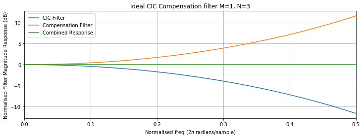

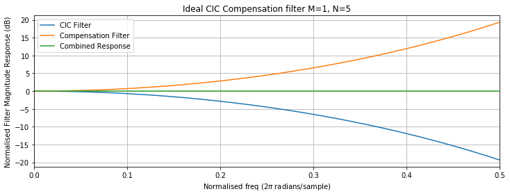

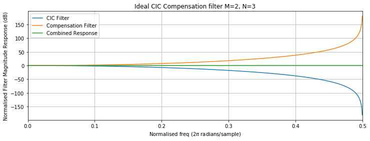

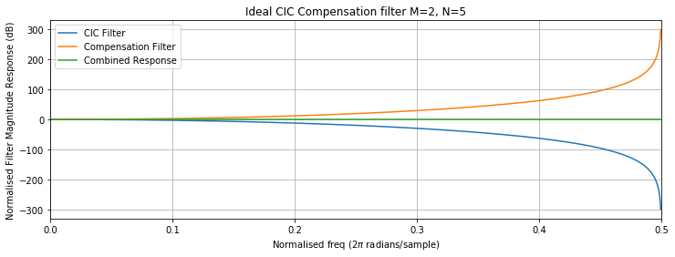

```python
def plotCICCompFilter(R,M,N):
    plt.figure(figsize=(12,4))
    w = np.arange(fftResolution) * np.pi/fftResolution
    xAxis = np.arange(fftResolution) / (fftResolution * 2)
    Hcomp = lambda w : ((M*R)**N)*(np.abs((np.sin(w/(2.*R))) / (np.sin((w*M)/2.)) ) **N)
    Hcic = lambda w : (1/((M*R)**N))*np.abs( (np.sin((w*M)/2.)) / (np.sin(w/(2.*R))) )**N

    cicMagResponse = np.array(list(map(Hcic, w)))
    cicCompResponse = np.array(list(map(Hcomp, w)))

    # Multiply frequency responses is a convolution in the time domain
    combine = cicCompResponse * cicMagResponse

    plt.plot(xAxis, 20.0*np.log10(cicMagResponse), label="CIC Filter")
    plt.plot(xAxis, 20.0*np.log10(cicCompResponse), label="Compensation Filter")
    plt.plot(xAxis, 20.0*np.log10(combine), label="Combined Response")

    axes = plt.gca(); axes.set_xlim([0,0.5]);
    plt.grid(); plt.legend()
    plt.title("Ideal CIC Compensation filter M={}, N={}".format(M,N))
    plt.xlabel('Normalised freq (2$\pi$ radians/sample)')
    plt.ylabel('Normalised Filter Magnitude Response (dB)')

    plt.show()

plotCICCompFilter(R=8,M=1,N=3)
plotCICCompFilter(R=8,M=1,N=5)
plotCICCompFilter(R=8,M=2,N=3)
plotCICCompFilter(R=8,M=2,N=5)
```

It can be seen how combining the ideal CIC response with the ideal compensation filter will give a flat passband. However, in practice it is not a good idea to achieve a flat response across the full Nyquist bandwidth with certain CIC filter configurations.

From these graphs we can make several observations.

1. The larger N is the greater attenuation in the passband of the CIC.
2. The passband attenuation when using M > 1 is very significant. M > 1 should only be used is the bandwidth of the signal of interest is a small proportion that provided by the lower sample rate of the CIC.

Typically, the bandwidth over which a flat passband is required is less than the Nyquist bandwidth. A couple of examples are shown below:

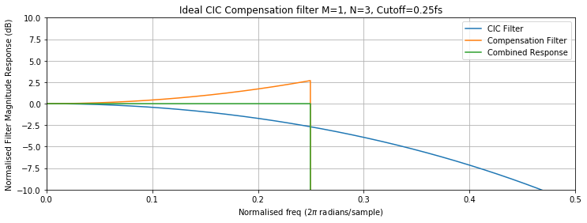

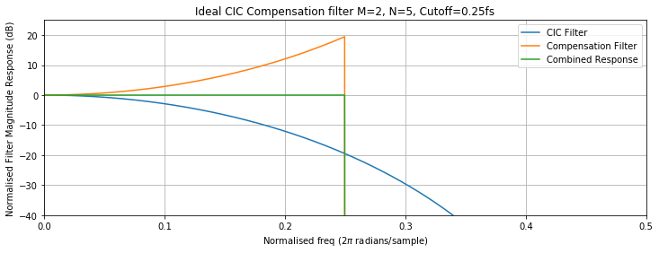

```python
def plotCICCompFilter(R,M,N, cutOff, yMin, yMax):
    plt.figure(figsize=(12,4))
    w = np.arange(fftResolution) * np.pi/fftResolution
    xAxis = np.arange(fftResolution) / (fftResolution * 2)
    Hcomp = lambda w : ((M*R)**N)*(np.abs((np.sin(w/(2.*R))) / (np.sin((w*M)/2.)) ) **N)
    Hcic = lambda w : (1/((M*R)**N))*np.abs( (np.sin((w*M)/2.)) / (np.sin(w/(2.*R))) )**N

    cicMagResponse = np.array(list(map(Hcic, w)))
    cicCompResponse = np.array(list(map(Hcomp, w)))
    # Stop band
    cicCompResponse[int(fftResolution*cutOff*2):] = np.finfo(float).eps

    # Multiply frequency responses is a convolution in the time domain
    combine = cicCompResponse * cicMagResponse

    plt.plot(xAxis, 20.0*np.log10(cicMagResponse), label="CIC Filter")
    plt.plot(xAxis, 20.0*np.log10(cicCompResponse), label="Compensation Filter")
    plt.plot(xAxis, 20.0*np.log10(combine), label="Combined Response")

    axes = plt.gca(); axes.set_xlim([0,0.5]); axes.set_ylim([yMin,yMax])
    plt.grid(); plt.legend()
    plt.title("Ideal CIC Compensation filter M={}, N={}, Cutoff={}fs".format(M,N,cutOff))
    plt.xlabel('Normalised freq (2$\pi$ radians/sample)')
    plt.ylabel('Normalised Filter Magnitude Response (dB)')

    plt.show()
plotCICCompFilter(R=8,M=1,N=3,cutOff=0.25,yMin=-10,yMax=10)
plotCICCompFilter(R=8,M=2,N=5,cutOff=0.25,yMin=-40,yMax=25)
```

### FIR Compensation Filter

CIC compensation filters are often implemented as FIR filters. The firwin2 function scipy can calculate FIR filter taps from an array of attenuation vs normalised frequency. This can be used to generate a filter with a profile matching that of a compensation filter.

```
Full Response
```

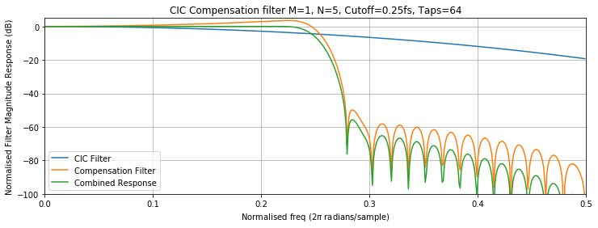

```
Zoom in on passband ripple
```

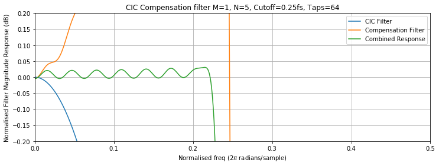

```python
from scipy.signal import firwin2
from scipy.signal import freqz

# Cut off is the cutOff as a fraction of the sample rate
# i.e 0.5 = nyquist frequency
def getFIRCompensationFilter(R,M,N,cutOff,numTaps,calcRes=1024):

    w = np.arange(calcRes) * np.pi/(calcRes - 1)
    Hcomp = lambda w : ((M*R)**N)*(np.abs((np.sin(w/(2.*R))) / (np.sin((w*M)/2.)) ) **N)
    cicCompResponse = np.array(list(map(Hcomp, w)))
    # Set DC response to 1 as it is calculated as 'nan' by Hcomp
    cicCompResponse[0] = 1
    # Set stopband response to 0
    cicCompResponse[int(calcRes*cutOff*2):] = 0
    normFreq = np.arange(calcRes) / (calcRes - 1)
    taps = firwin2(numTaps, normFreq, cicCompResponse)
    return taps

def plotFIRCompFilter(R,M,N,cutOff,taps, yMin, yMax, wideband=False):

    plt.figure(figsize=(12,4))

    if wideband:
        interp = np.zeros(len(taps)*R)
        interp[::R] = taps
        freqs,response = freqz(interp)
    else:
        freqs,response = freqz(taps)

    if wideband:
        w = np.arange(len(freqs)) * np.pi/len(freqs) * R
    else:
        w = np.arange(len(freqs)) * np.pi/len(freqs)

    Hcic = lambda w : (1/((M*R)**N))*np.abs( (np.sin((w*M)/2.)) / (np.sin(w/(2.*R))) )**N
    cicMagResponse = np.array(list(map(Hcic, w)))

    combinedResponse = cicMagResponse * response

    plt.plot(freqs/(2*np.pi),20*np.log10(abs(cicMagResponse)), label="CIC Filter")
    plt.plot(freqs/(2*np.pi),20*np.log10(abs(response)), label="Compensation Filter")
    plt.plot(freqs/(2*np.pi),20*np.log10(abs(combinedResponse)), label="Combined Response")
    axes = plt.gca(); axes.set_xlim([0,0.5]); axes.set_ylim([yMin,yMax])
    plt.grid(); plt.legend()
    plt.title("CIC Compensation filter M={}, N={}, Cutoff={}fs, Taps={}".format(M,N,cutOff,len(taps)))
    plt.xlabel('Normalised freq (2$\pi$ radians/sample)')
    plt.ylabel('Normalised Filter Magnitude Response (dB)')
    plt.show()

taps = getFIRCompensationFilter(R=8,M=1,N=5,cutOff=0.25,numTaps=64);
print("Full Response")
plotFIRCompFilter(R=8,M=1,N=5,cutOff=0.25,taps=taps,yMin=-100,yMax=5)
print("Zoom in on passband ripple")
plotFIRCompFilter(R=8,M=1,N=5,cutOff=0.25,taps=taps,yMin=-0.2,yMax=0.2)
```

```
Full Response
```

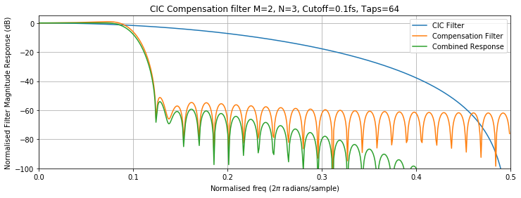

```
Zoom in on passband ripple
```

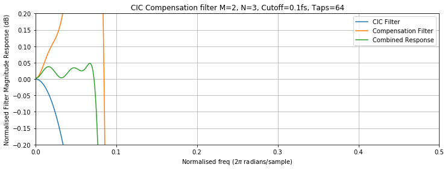

```python
taps = getFIRCompensationFilter(R=8,M=2,N=3,cutOff=0.1,numTaps=64);
print("Full Response")
plotFIRCompFilter(R=8,M=2,N=3,cutOff=0.1,taps=taps,yMin=-100,yMax=5)
print("Zoom in on passband ripple")
plotFIRCompFilter(R=8,M=2,N=3,cutOff=0.1,taps=taps,yMin=-0.2,yMax=0.2)
```

```
Full Response
```

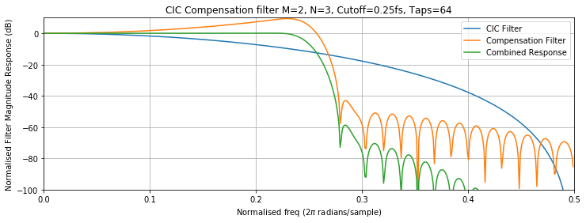

```
Zoom in on passband ripple
```

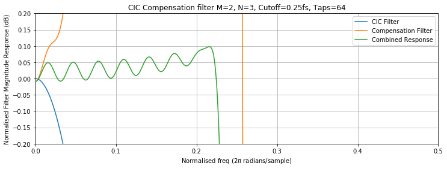

```python
taps = getFIRCompensationFilter(R=8,M=2,N=3,cutOff=0.25,numTaps=64);
print("Full Response")
plotFIRCompFilter(R=8,M=2,N=3,cutOff=0.25,taps=taps,yMin=-100,yMax=10)
print("Zoom in on passband ripple")
plotFIRCompFilter(R=8,M=2,N=3,cutOff=0.25,taps=taps,yMin=-0.2,yMax=0.2)
```

Some examples of how changing different parameters effects the frequency response are shown below:

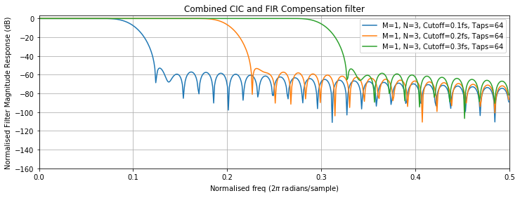

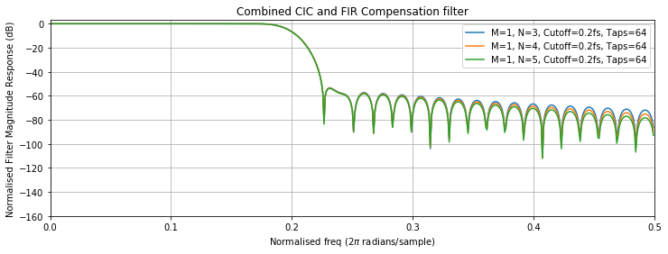

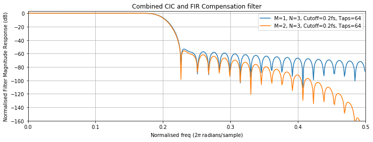

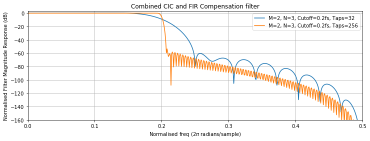

```python
def plotFIRCombinedFilter(R,M,N,cutOff,taps,wideband=False):
    if wideband:
        interp = np.zeros(len(taps)*R)
        interp[::R] = taps
        freqs,response = freqz(interp)
    else:
        freqs,response = freqz(taps)

    if wideband:
        w = np.arange(len(freqs)) * np.pi/len(freqs) * R
    else:
        w = np.arange(len(freqs)) * np.pi/len(freqs)

    Hcic = lambda w : (1/((M*R)**N))*np.abs( (np.sin((w*M)/2.)) / (np.sin(w/(2.*R))) )**N
    cicMagResponse = np.array(list(map(Hcic, w)))
    combinedResponse = cicMagResponse * response
    plt.plot(freqs/(2*np.pi),20*np.log10(abs(combinedResponse)), label="M={}, N={}, Cutoff={}fs, Taps={}".format(M,N,cutOff,len(taps)))
    axes = plt.gca();axes.set_xlim([0,0.5]); axes.set_ylim([-160,3])
    plt.grid(); plt.legend();
    plt.title("Combined CIC and FIR Compensation filter")
    plt.xlabel('Normalised freq (2$\pi$ radians/sample)')
    plt.ylabel('Normalised Filter Magnitude Response (dB)')

plt.figure(figsize=(12,4))
taps = getFIRCompensationFilter(R=8,M=1,N=3,cutOff=0.1,numTaps=64);
plotFIRCombinedFilter(R=8,M=1,N=3,cutOff=0.1,taps=taps)
taps = getFIRCompensationFilter(R=8,M=1,N=3,cutOff=0.2,numTaps=64);
plotFIRCombinedFilter(R=8,M=1,N=3,cutOff=0.2,taps=taps)
taps = getFIRCompensationFilter(R=8,M=1,N=3,cutOff=0.3,numTaps=64);
plotFIRCombinedFilter(R=8,M=1,N=3,cutOff=0.3,taps=taps)
plt.show()

plt.figure(figsize=(12,4))
taps = getFIRCompensationFilter(R=8,M=1,N=3,cutOff=0.2,numTaps=64);
plotFIRCombinedFilter(R=8,M=1,N=3,cutOff=0.2,taps=taps)
taps = getFIRCompensationFilter(R=8,M=1,N=4,cutOff=0.2,numTaps=64);
plotFIRCombinedFilter(R=8,M=1,N=4,cutOff=0.2,taps=taps)
taps = getFIRCompensationFilter(R=8,M=1,N=5,cutOff=0.2,numTaps=64);
plotFIRCombinedFilter(R=8,M=1,N=5,cutOff=0.2,taps=taps)
plt.show()

plt.figure(figsize=(12,4))
taps = getFIRCompensationFilter(R=8,M=1,N=3,cutOff=0.2,numTaps=64);
plotFIRCombinedFilter(R=8,M=1,N=3,cutOff=0.2,taps=taps)
taps = getFIRCompensationFilter(R=8,M=2,N=3,cutOff=0.2,numTaps=64);
plotFIRCombinedFilter(R=8,M=2,N=3,cutOff=0.2,taps=taps)
plt.grid();
plt.show()

plt.figure(figsize=(12,4))
taps = getFIRCompensationFilter(R=8,M=2,N=3,cutOff=0.2,numTaps=32);
plotFIRCombinedFilter(R=8,M=2,N=3,cutOff=0.2,taps=taps)
taps = getFIRCompensationFilter(R=8,M=2,N=3,cutOff=0.2,numTaps=256);
plotFIRCombinedFilter(R=8,M=2,N=3,cutOff=0.2,taps=taps)
plt.grid();
plt.show()
```

#### CIC compensation filter - Wideband response

To get a proper idea of the response of the compensation filter it is necessary to plot the frequency response over the larger bandwidth of the CIC filter.  
In the first example below a cut off frequency of 0.1 times the lower sample rate is used. The combination of the narrow FIR bandwidth around the nulls in the CIC frequency response means the addition of the compensation filter improves the overall wideband response of the system. In the second example the cut off frequency is set to 0.4 times the lower sample rate. The wide bandwidth of the compensation filter as well as the gain it adds to compensate for passband attenuation mean that the combined wideband frequency response is worse than the CIC on its own.

A rule of thumb is that the cut off frequency should be less than the lower sample rate / 4M.

If this condition cannot be met it is better to do the sample rate change in two stages with FIR compensation filter performing an interpolation or decimation by 2.

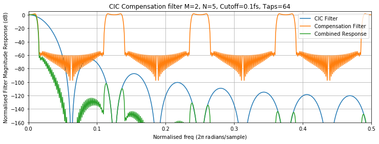

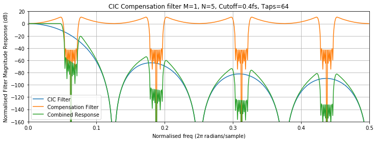

```python
taps = getFIRCompensationFilter(R=8,M=2,N=5,cutOff=0.1,numTaps=64);
plotFIRCompFilter(R=8,M=2,N=5,cutOff=0.1,taps=taps,yMin=-160,yMax=5,wideband=True)

taps = getFIRCompensationFilter(R=8,M=1,N=5,cutOff=0.4,numTaps=64);
plotFIRCompFilter(R=8,M=1,N=5,cutOff=0.4,taps=taps,yMin=-160,yMax=20,wideband=True)
```

As discussed previously it is typically not a good idea to compensate over the full bandwidth of the lower sample rate. The two graphs below show the narrow and wideband responses when this operation is performed. It can be seen how the wideband performance of the CIC is made worse.

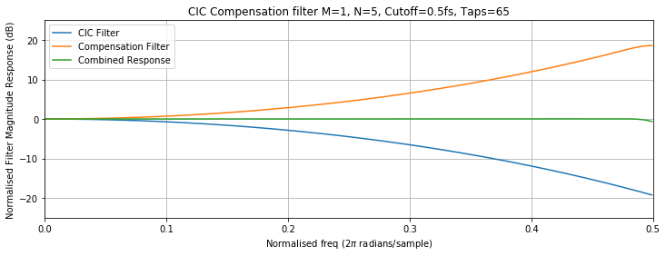

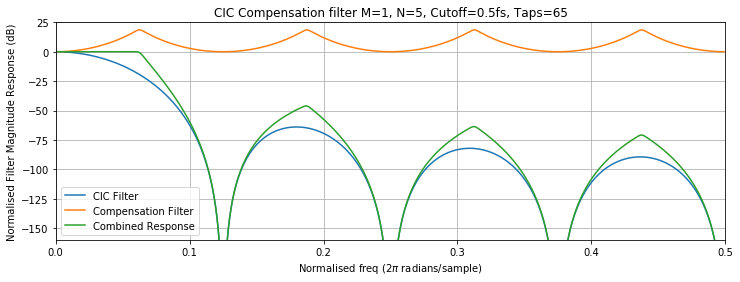

```python
taps = getFIRCompensationFilter(R=8,M=1,N=5,cutOff=0.5,numTaps=65);
plotFIRCompFilter(R=8,M=1,N=5,cutOff=0.5,taps=taps,yMin=-25,yMax=25,wideband=False)
plotFIRCompFilter(R=8,M=1,N=5,cutOff=0.5,taps=taps,yMin=-160,yMax=25,wideband=True)
```

This final graph shows the combined CIC and FIR response when the cut off frequency is set to several different values. NB. the unlabelled response is just the CIC response without a compensation filter.

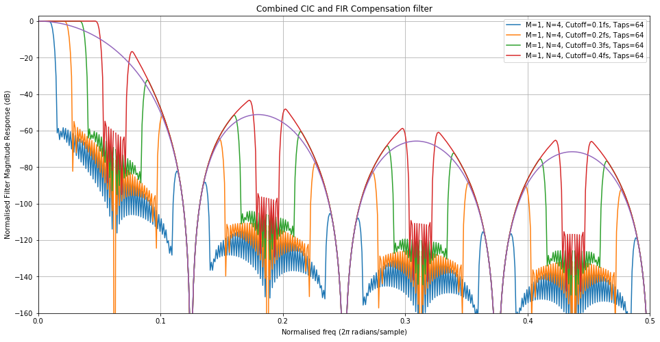

```python
plt.figure(figsize=(16,8))
taps = getFIRCompensationFilter(R=8,M=1,N=4,cutOff=0.1,numTaps=64);
plotFIRCombinedFilter(R=8,M=1,N=4,cutOff=0.1,taps=taps, wideband=True)
taps = getFIRCompensationFilter(R=8,M=1,N=4,cutOff=0.2,numTaps=64);
plotFIRCombinedFilter(R=8,M=1,N=4,cutOff=0.2,taps=taps, wideband=True)
taps = getFIRCompensationFilter(R=8,M=1,N=4,cutOff=0.3,numTaps=64);
plotFIRCombinedFilter(R=8,M=1,N=4,cutOff=0.3,taps=taps, wideband=True)
taps = getFIRCompensationFilter(R=8,M=1,N=4,cutOff=0.4,numTaps=64);
plotFIRCombinedFilter(R=8,M=1,N=4,cutOff=0.4,taps=taps, wideband=True)
plt.grid();
plotCICResponse(R=8,M=1,N=4, widebandResponse=True)
```